# Medical Data Analysis

### Insights from Patients demography data

Male in urban residence are highest for No immunization status at 16.05% of total population

Female in urban residence are highest for complete immunization status at 3.56%

Female in rural residence are highest for partial immunization status at 6.13%

Plateau registers highest number for No immunization status with count of 816

Rivers registers highest for complete immunization with count of 196 while Kaduna is lowest with count of 149

For partial registration, Kaduna ranks highest with count of 334, while Kano is least with count of 284

Plateau ranks highest for insurance coverage with a count of 654 with Kano least with count of 580

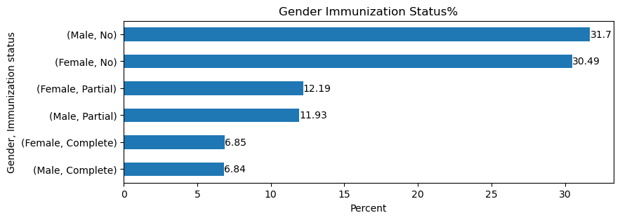

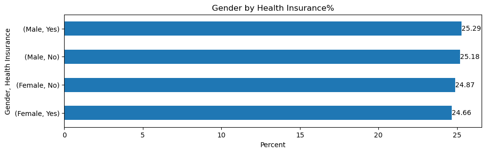

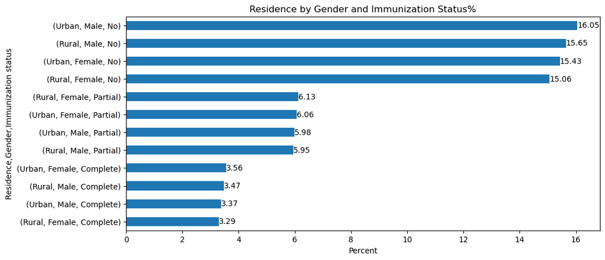

```
Immunization count: 10000
```

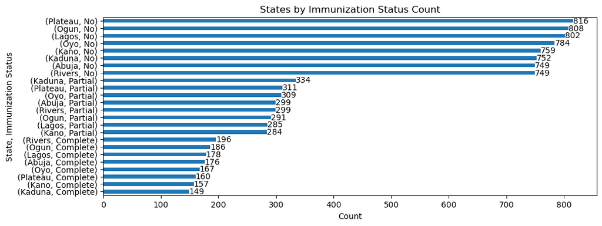

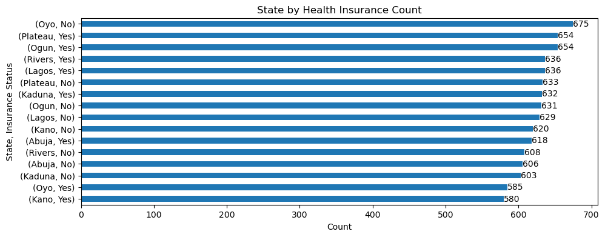

### Insights from Health Center Ops dataset

Kaduna ranks highest for facility types with total number of 17

Ogun ranks lowest with a total of 8

Avg wait time is highest for specialist hospitals at 36.8mins

Avg wait time is lowest for clinics at 30.65mins

Out patient visits are highest in teaching hospital at 24.27% of total visits and lowest for primary health centers at 10.63%

In patient admission are highest for teaching hospital at 24% and lowest for primary health centers at 10.71% of populace

Access to essential medicine are highest for teaching hospital with 23 getting proucts and lowest for primary health centers with just 3 access the proucts

Primary health centers unable to access medicine are 9 with just one of the teaching unable to get product

Avg patient per doctor by facility is highest for specialist hospital with count of 21 patient/doctor and lowest for medical centers with a count of 16 patients/doctor

Bed occupancy is highest for Kaduna with a count of 99 an lowest in Ogun specialist hospital with a count of 53

Plateau registers the highest outpatient visit at 15.86% while Ogun is least with 8.24% of the population

Kaduna ranks highest for inpatient admission with 17.91% while Ogun is the least at 7.79% of the total population

```
Total facilities:  101
```

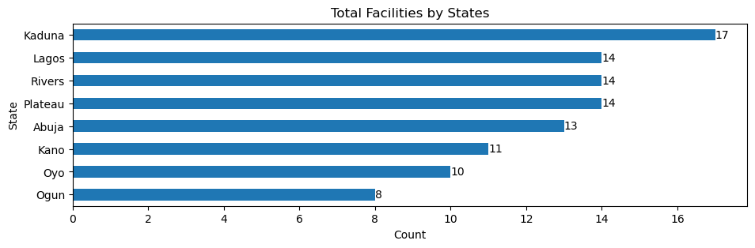

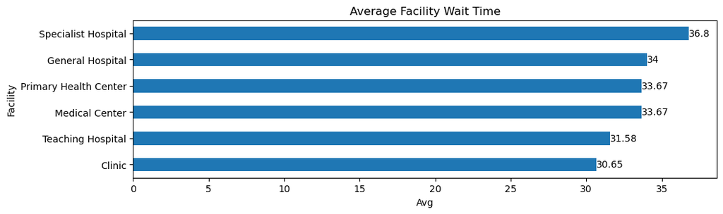

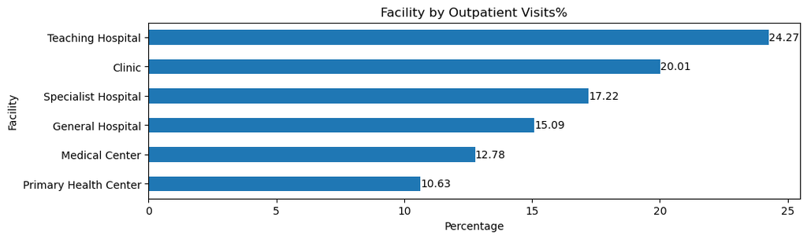

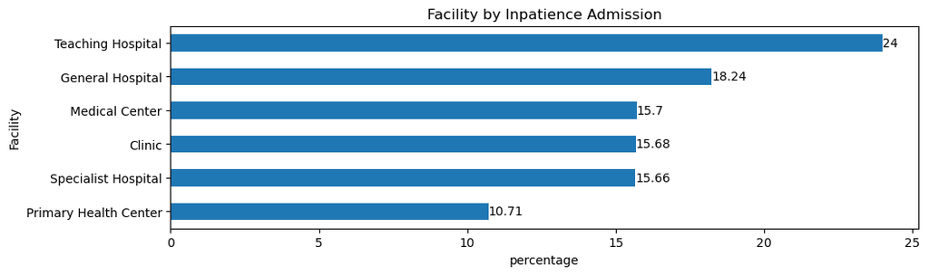

```
Total access:  64
```

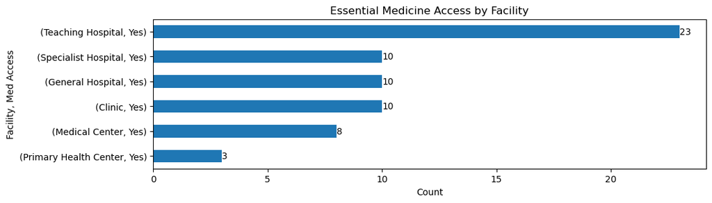

```
No access :  36
```

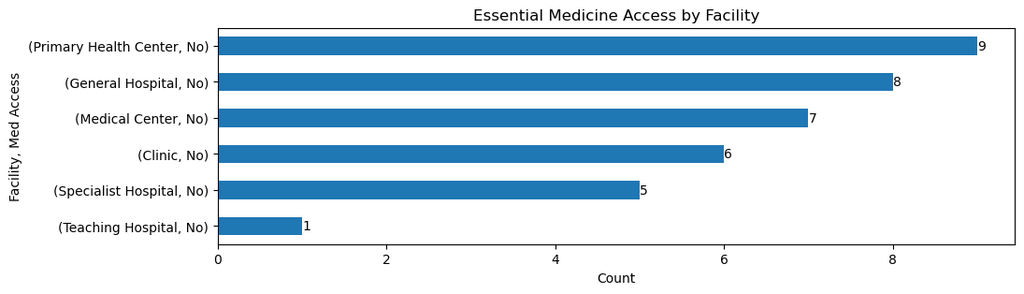

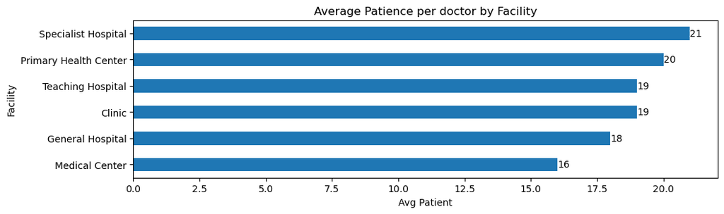

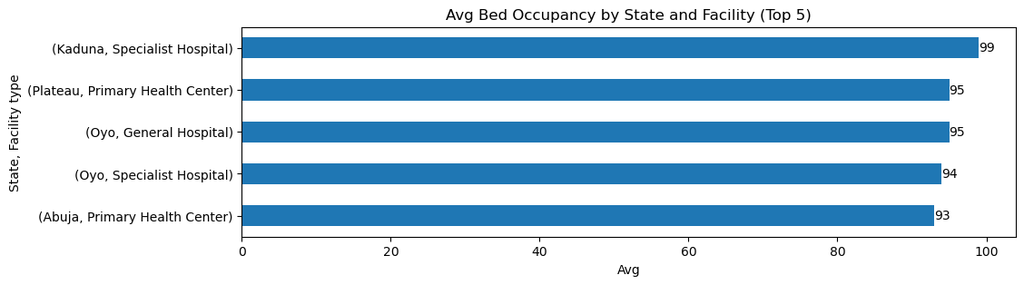

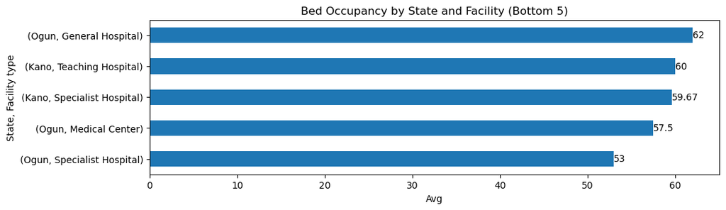

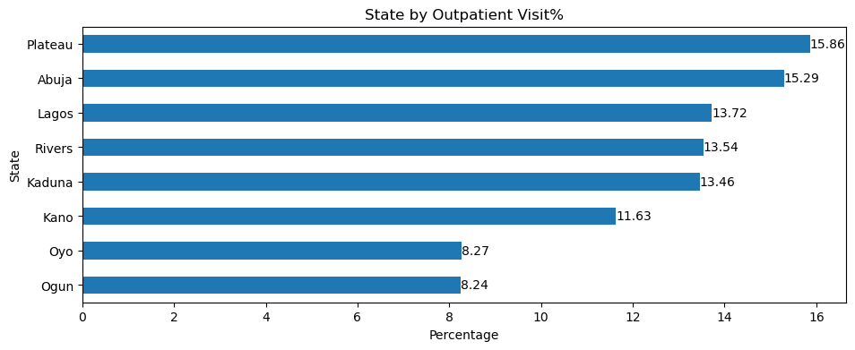

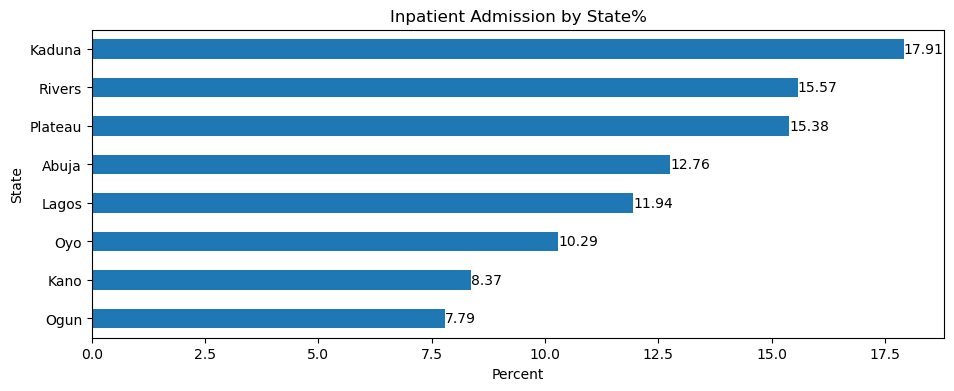

### Insights from Patient Visit dataset

Check-up ranks highest for reason of visit at 25.05% of population and lowest for ongoing treatment at 8.62%

Emergengy ranks highest recovery at 19.48% while ongoing treatmeant was least at 6.66%

Death rate was highest for emergency at 0.66 and lowest for ongoing treatment at 0.24%

Health center 135 (Plateau teaching hospital) recorded the highest recovery at 104 count, while health center 122 (Abuja primary health care) and health center 104 (Plateau general hospital) recorded the most death with count 7 simultaneously.

Health center 143 (Ogun medical center) recorded the worst deterioration with a count of 34

Malaria ranks highest diagnosis recovery with a count of 1644 and tuberculosis least at 838

Treatment by medication ranks highest for recovery at count of 4537 while surgery was least at 1355

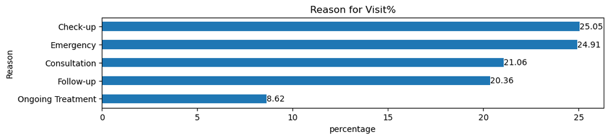

```
Recovered:     7724     77.24 %
Deteriorated:  2084     20.84 %
Death:          192     1.92 %
```

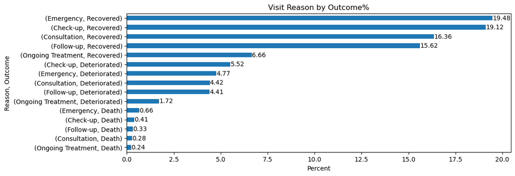

```
Recovered:     7724
Total Centers: 10000
```

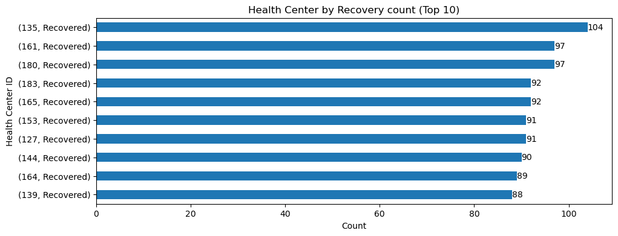

```
Total Death:   192
Total Centers: 10000
```

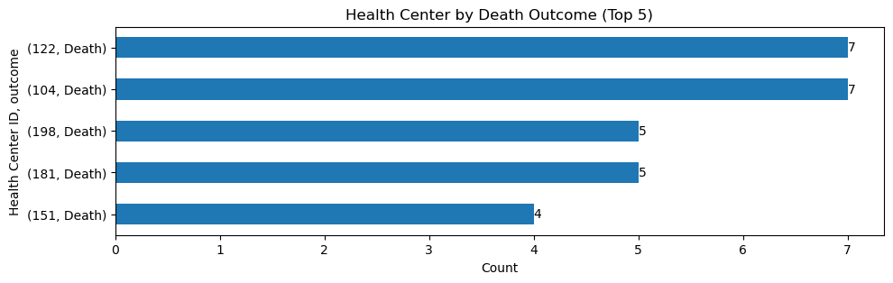

```
Deteriorated count:  2084
Total Centers:       10000
```

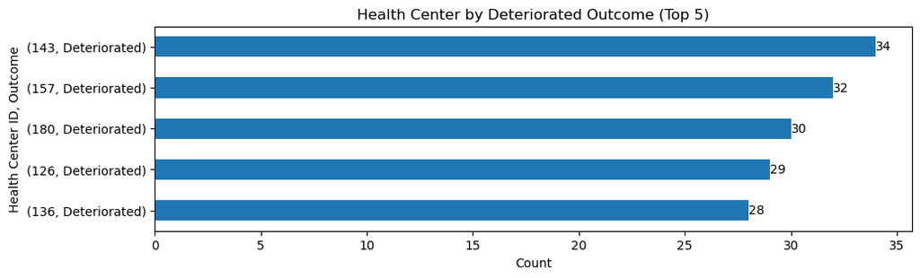

```
Recovered: 7724
Malaria:   1644     21.28 %
```

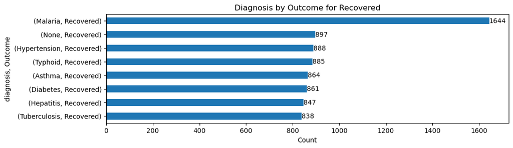

```
Recovered:   7724
medication:  4537    58.74 %
```

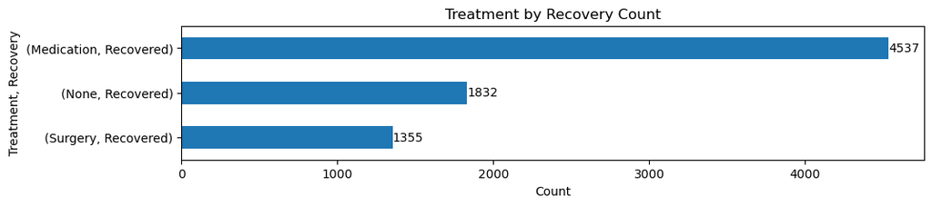

### Insights from Patients Satisfaction dataset

Health center 155 (Kano primary health center) was highest rated with a rating of 5

Health center 164 (Plateau specialist hospital) and health center 114 (Kano medical center ) was worst rated with a rating of 1

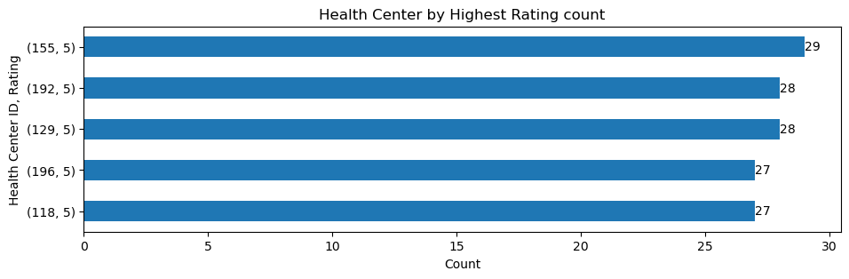

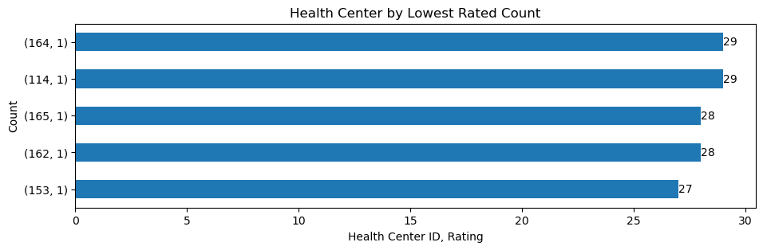

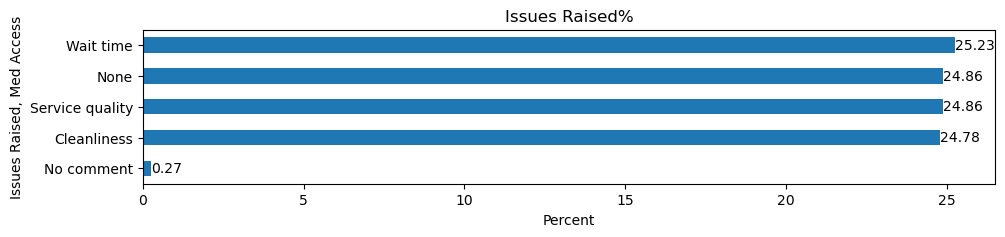

### Recommendations

Increase female access to insurance to level up with the male gender

Ogun state medical facilities require attention to improve poor performance

Primary health center accross all locations should get increased support in terms of accessing essential medicine

Average wait should be improved as patients prioritised it over service quality

Except surgery is absolutely necessary, medication seem to be a worthy alternative